# limpa case study: two groups with DIA-NN quantification

Mengbo Li and Gordon K. Smyth

First version 9 December 2025, Last revised 25 March 2026

# Introduction

This case study analyses the HYE100 hybrid proteome samples from Navarro et al (2016). Two samples, A and B, were prepared by mixing human, yeast and E. coli tryptic peptides in specified proportions. The human peptides was obtained from HeLa cells, which is a cervical cancer cell line. Sample A was composed of 67% human, 30% yeast, and 3% E. coli, while sample B was composed of 67% human, 3% yeast, and 30% E. coli. The human proteins should not be differentially expressed between A and B, while yeast proteins should be 10-fold up-regulated in A, and E. coli proteins should be 10-fold up-regulated in B. Three technical replicates were prepared of A and B, to make a two group experiment with $n=3$ samples in each group.

Demichev et al (2020) re-processed the mass spectrometry data using DIA-NN version 1, and the DIA-NN report file with the precursor quantifications can be downloaded from https://doi.org/10.17605/OSF.IO/6G3UX. The data has also been analyzed by Li et al (2025).

We use this data for two purposes. First, we use it as an example analysis using DIA-NN data. Second, we explore the data a little more to illustrate the advantages and limitations of a mixed-species dataset such as this.

This vignette was made with limpa version 1.3.10 and limma version 3.67.1.

# Example analysis

The precursor ion intensities are provided in a tab-delimited report file output by DIA-NN, which we can read into limpa using `readDIANN()`:

```r
> library(limpa)
> y.prec <- readDIANN("Fig2-diann.tsv",
+              run.column="File.Name",
+              q.columns=c("Q.Value","Protein.Q.Value"),
+              annotation.columns="Protein.Group")
```

```
Filtered 2196 q-values above q.cutoffs.
```

```r
> dim(y.prec)
```

```
[1] 41919     6
```

This produces a dataset with 41919 rows (precursors) and 6 columns (samples).

The samples are in two groups.

```r
> Replicate <- factor(c(1,1,2,2,3,3))
> Group <- factor(c("A","B","A","B","A","B"))
> colnames(y.prec) <- paste(Group, Replicate, sep=".")
```

Add a species annotation column:

```r
> PG <- y.prec$genes$Protein.Group
> n <- nchar(PG)
> y.prec$genes$Species <- substring(PG,n-4L,n)
> table(y.prec$genes$Species)
```

```
ECOLI HUMAN YEAS8
12260 16882 12777
```

As usualy, we can see a relationship between the average observed intensity1 and the number of missing values for each precursor:

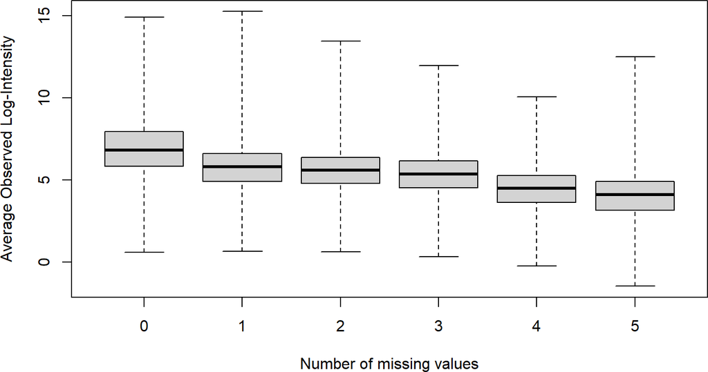

```r
> plotAveVsMis(y.prec)
```

We find that a detection probability slope of about 0.7 is generally appropriate for current mass spectrometry technology and DIA-NN quantification. It would be acceptable to simply run `dpcQuant()` with `dpc.slope = 0.7`, but we check the assumption here using `dpcCN()`, and find that the detection probability slope is estimated to be about 0.6. We estimate DPC here from the complete-normal model using `dpcCN` because it is robust to very large fold-changes in the data.

```r
> dpcest <- dpcCN(y.prec)
> dpcest$dpc
```

```
beta0 beta1
-2.19  0.59
```

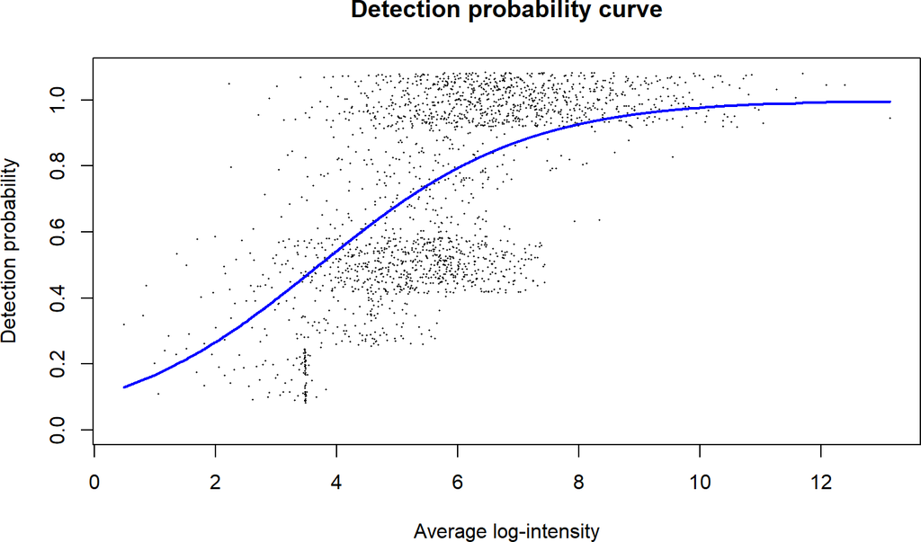

```r
> plotDPC(dpcest)
```

Quantify protein expression:

```r
> y <- dpcQuant(y.prec, dpc=dpcest)
```

```
Estimating hyperparameters ...
```

```
Quantifying proteins ...
```

```
Proteins: 1000  Precursors: 9001 (21%)
```

```
Proteins: 2000  Precursors: 17399 (41%)
```

```
Proteins: 3000  Precursors: 24460 (58%)
```

```
Proteins: 4000  Precursors: 29422 (70%)
```

```
Proteins: 5000  Precursors: 36667 (87%)
```

```
Proteins: 6000  Precursors: 40815 (97%)
```

```
Proteins: 6430  Precursors: 41919 (100%)
```

```r
> dim(y)
```

```
[1] 6430    6
```

At this stage, it is usual to filter out proteins that are insufficiently expressed. We will keep proteins in the DE anaysis that are detected, at least once, in at least three samples:

```r
> keep <- filterByDetection(y, n.samples=3)
> yfilt <- y[keep,]
> dim(yfilt)
```

```
[1] 6004    6
```

The A and B samples separate very clearly, showing that there is considerable DE in the data:

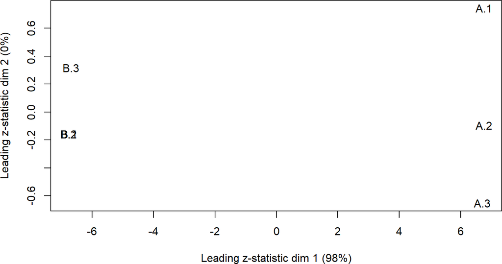

```r
> plotMDSUsingSEs(yfilt)
```

Now we form the design matrix and proceed to differential expression analysis. First, limpa identifies a clear variance trend that will be used in the empirical Bayes modelling:

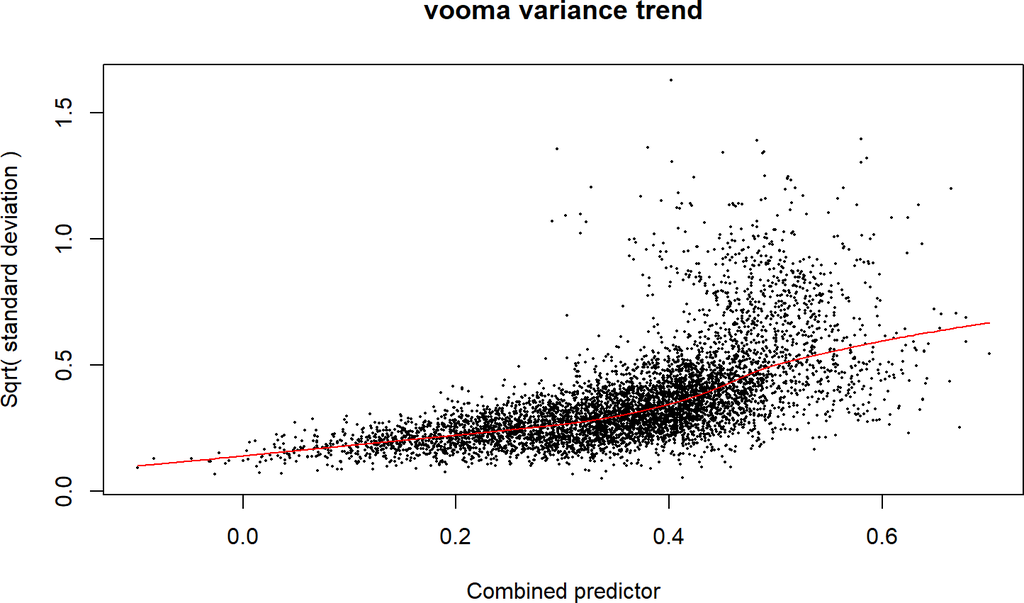

```r
> design <- model.matrix(~Group)
> fit <- dpcDE(yfilt, design, plot=TRUE)
```

Differential expression analysis identifies Yeast and E. coli samples as highly signficant:

```r
> fit <- eBayes(fit)
> summary(dt <- decideTests(fit[,2]))
```

```
       GroupB
Down     1957
NotSig   2254
Up       1793
```

```r
> topTable(fit, coef=2, n=10)
```

```
                                                Species NPrec PropObs  logFC AveExpr       t   P.Value adj.P.Val     B
1/tr|C8ZD01|C8ZD01_YEAS8                          YEAS8     2  1.0000 -3.519   8.881 -120.64 1.809e-14 4.631e-11 24.04
1/sp|P0A7N9|RL33_ECOLI                            ECOLI     2  1.0000  3.286   8.466  117.40 2.254e-14 4.631e-11 23.81
1/tr|C8ZG50|C8ZG50_YEAS8                          YEAS8    17  0.9216 -3.481   7.097 -115.27 2.613e-14 4.631e-11 23.65
1/sp|P0A910|OMPA_ECOLI                            ECOLI    25  0.8400  3.289   7.854  112.93 3.085e-14 4.631e-11 23.57
1/sp|P69908|DCEA_ECOLI                            ECOLI     2  1.0000  3.387   8.295  107.84 4.481e-14 5.381e-11 23.13
2/tr|C8ZF58|C8ZF58_YEAS8/tr|C8ZIC9|C8ZIC9_YEAS8   YEAS8     4  0.8750 -3.337   7.219 -101.31 7.430e-14 7.435e-11 22.72
1/sp|P02768|ALBU_HUMAN                            HUMAN     2  1.0000 -2.551   9.524  -99.29 8.747e-14 7.502e-11 22.59
1/tr|C8Z3F1|C8Z3F1_YEAS8                          YEAS8    53  0.7516 -3.607   6.290  -93.04 1.480e-13 1.030e-10 21.90
1/sp|P0A8V2|RPOB_ECOLI                            ECOLI    78  0.7286  3.277   5.083   92.24 1.587e-13 1.030e-10 21.88
1/tr|C8Z4U5|C8Z4U5_YEAS8                          YEAS8     9  0.9444 -3.434   6.856  -91.36 1.715e-13 1.030e-10 21.86
```

A mean-difference plot shows that limpa recovers correct fold-changes for most protein, even single-precursor proteins and those at very low intensities:

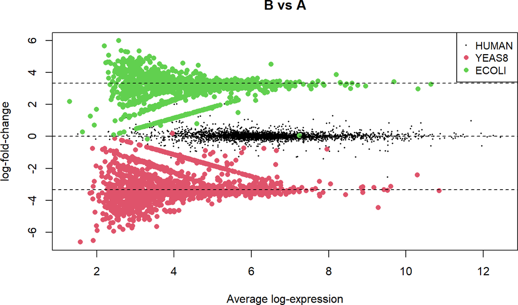

```r
> plotMD(fit, coef=2, status=fit$genes$Species, main="B vs A")
> abline(h=log2(10), lty=2)
> abline(h=0, lty=2)
> abline(h=-log2(10), lty=2)
```

The plot becomes clearer if we restrict to proteins with two or more precursors:

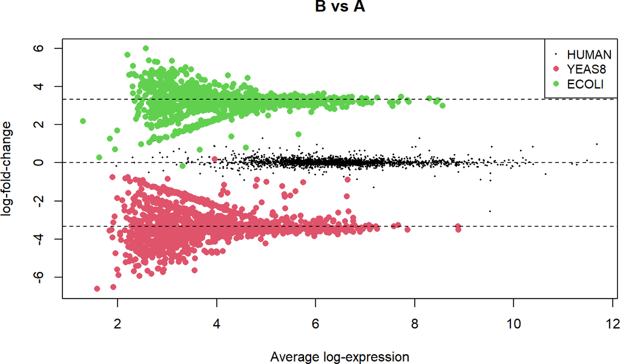

```r
> i <- which(fit$genes$NPrec>1)
> plotMD(fit[i,], coef=2, status=fit$genes$Species[i], main="B vs A")
> abline(h=log2(10),lty=2)
> abline(h=0, lty=2)
> abline(h=-log2(10),lty=2)
```

# Proteins that are entirely missing in one group

One of the advantages of limpa is its ability to assess DE even for proteins that are entirely missing in one of the groups. We can compute the number of non-missing observations for each protein in each group:

```r
> NObs.A <- rowSums(yfilt$other$n.observations[,c(1,3,5)])
> NObs.B <- rowSums(yfilt$other$n.observations[,c(2,4,6)])
```

```r
> table(DE=dt, Nobs.A=pmin(NObs.A,5))
```

```
    Nobs.A
DE      0    1    2    3    4    5
  -1    0    0    4  339   41 1573
  0    30   24  101  651   31 1417
  1   592   83   72  182   38  826
```

```r
> table(DE=dt, Nobs.B=pmin(NObs.B,5))
```

```
    Nobs.B
DE      0    1    2    3    4    5
  -1  919   95   72  198   40  633
  0    34   27   94  649   40 1410
  1     0    0    6  260   16 1511
```

We can confirm that these significant proteins are correct discoveries:

```r
> table(fit$genes$Species[dt==  1 & NObs.A==0])
```

```
ECOLI HUMAN YEAS8
  581    10     1
```

```r
> table(fit$genes$Species[dt== -1 & NObs.B==0])
```

```
HUMAN YEAS8
    5   914
```

We see the 581 of the 592 up proteins are correct discoveries and the 914 of the 919 down proteins are correct discoveries. This represents a FDR of just over 1%.

As as example, we pick out most significant of the latter proteins:

```r
> PValue <- fit$p.value[,2]
> PGB <- names(which.min(PValue[NObs.B==0]))
```

Plot the protein quantifications with standard errors:

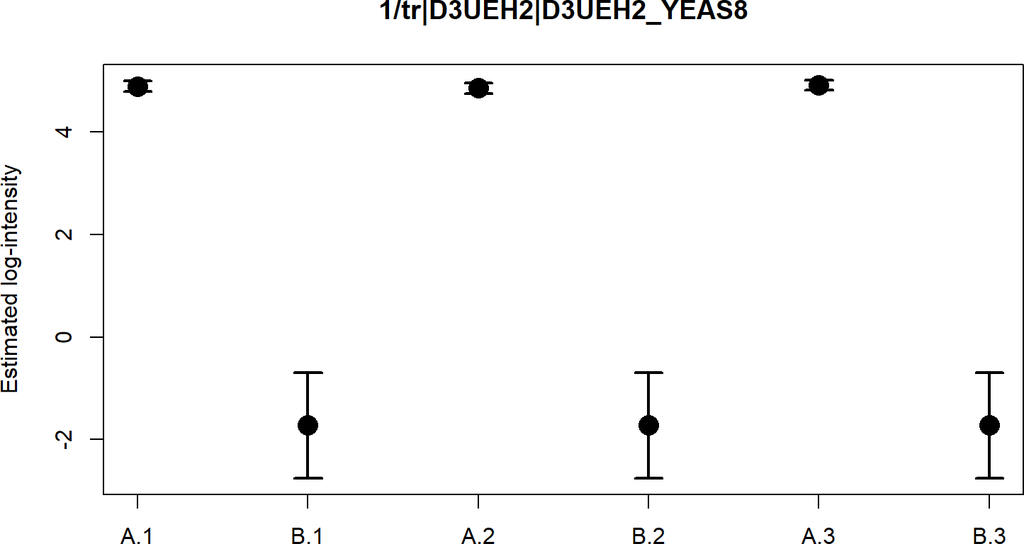

```r
> plotProtein(y, PGB, main=PGB)
```

Now plot the corresponding precursor log-intensities. This yeast protein has 39 precursors, all of which are missing in all the B samples. In plot, closed circles indicate observations and open circles indicate missing values. For the purposes of the plot, the missing values are plotted 0.5 units below the minimum observation for the same precursor:

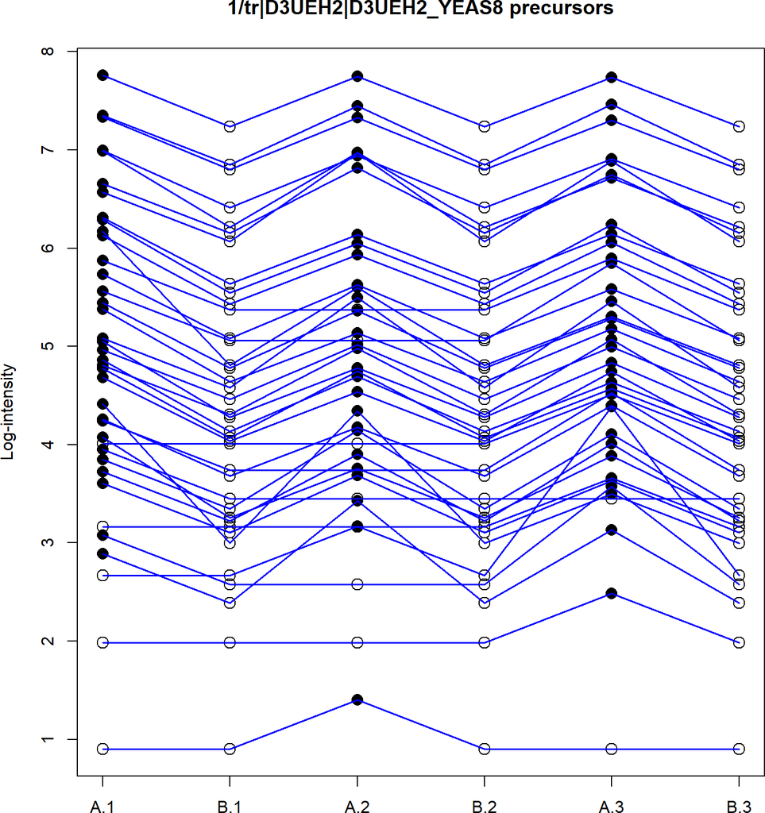

```r
> plotPeptides(y.prec[y.prec$genes$Protein.Group==PGB,],
+              main=paste(PGB,"precursors"))
```

# Normalization seems unnecessary

We did not do any extra normalization on top of that already done by DIA-NN. The human proteins seem equally distributed between samples, so no extra normalization seems necessary:

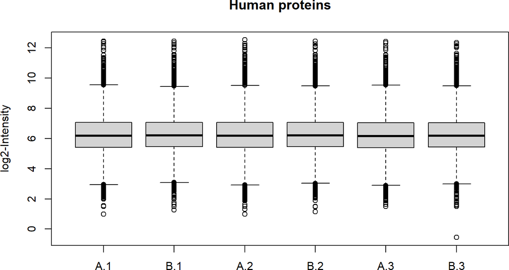

```r
> isH <- which(y$genes$Species == "HUMAN")
> boxplot(as.data.frame(y$E[isH,]),
+         ylab="log2-Intensity", main="Human proteins")
```

As expected, the yeast proteins are lower in B samples:

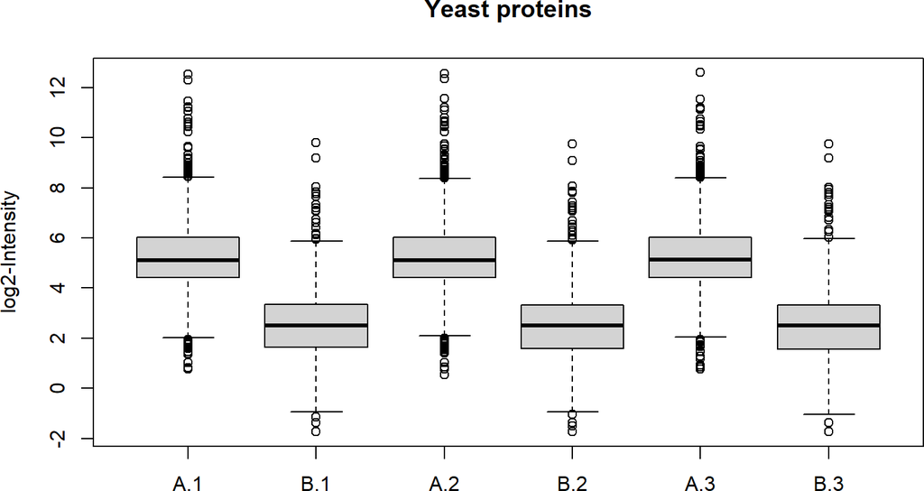

```r
> isY <- which(y$genes$Species == "YEAS8")
> boxplot(as.data.frame(y$E[isY,]),
+         ylab="log2-Intensity", main="Yeast proteins")
```

while the E. coli proteins are lower in A samples:

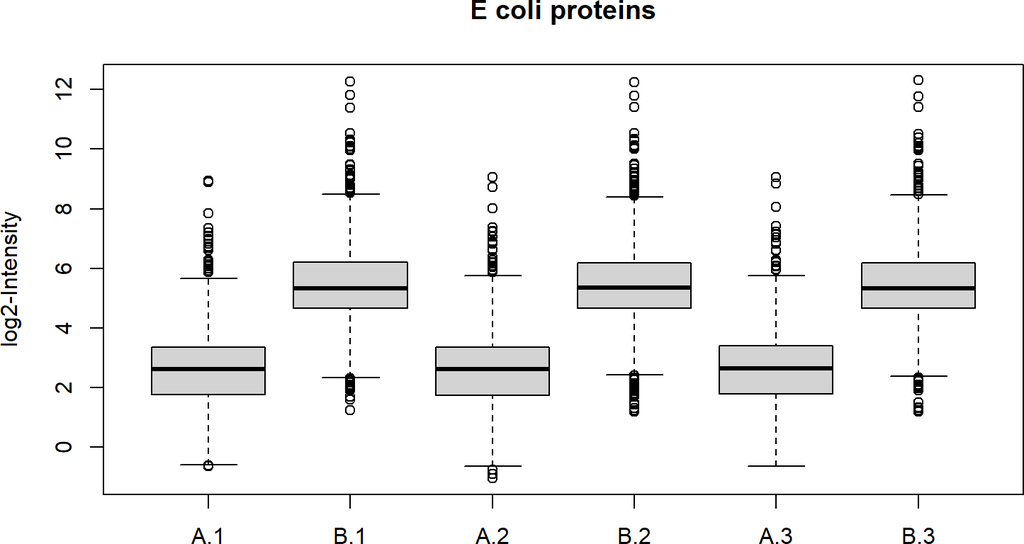

```r
> isE <- which(y$genes$Species == "ECOLI")
> boxplot(as.data.frame(y$E[isE,]),
+        ylab="log2-Intensity", main="E coli proteins")
```

# Confirming that missingness is intensity-dependent

Now we explore the pattern of missing values at the precursor level:

```r
> NMissing.A <- rowSums(is.na(y.prec$E[,Group=="A"]))
> NMissing.B <- rowSums(is.na(y.prec$E[,Group=="B"]))
> table(NMissing.A, y.prec$genes$Species)
```

```
NMissing.A ECOLI HUMAN YEAS8
         0  2851 15021 10281
         1   895  1064  1484
         2  1137   493   988
         3  7377   304    24
```

```r
> table(NMissing.B, y.prec$genes$Species)
```

```
NMissing.B ECOLI HUMAN YEAS8
         0 10240 14966  1818
         1  1215   990   744
         2   793   623   951
         3    12   303  9264
```

We see that human precursors have similar numbers of missing values in A and B samples, while E. coli precursors have far more missing values in A and yeast precursors have far more missing values in B samples. This confirms that the missing values are intensity-dependent, because the missingness pattern correlates with global changes in precursor intensities.

# Limitations of this dataset

This dataset was created by Navarro et al (2016) and Demichev et al (2020) in order to benchmark peptide quantification algorithms. The dataset is, however, different from real biological datasets in a number of ways that make it unsuitable for benchmarking differential expression statistical methods. One issue that is that the DE proteins and precursors have systematically lower intensities (and consequently more missing values) than the non-DE proteins and precursors. Another issue is that log-fold-changes are very large, while the variation between replicates is very small and not representative of biological variation. Another issue is that the dataset contains false positives, whereby some of the human proteins are clearly differentially expressed, although the experimental design should have ensured that they were not. A striking example of a DE human protein is albumin, for which both precursors are clearly down in the B samples:

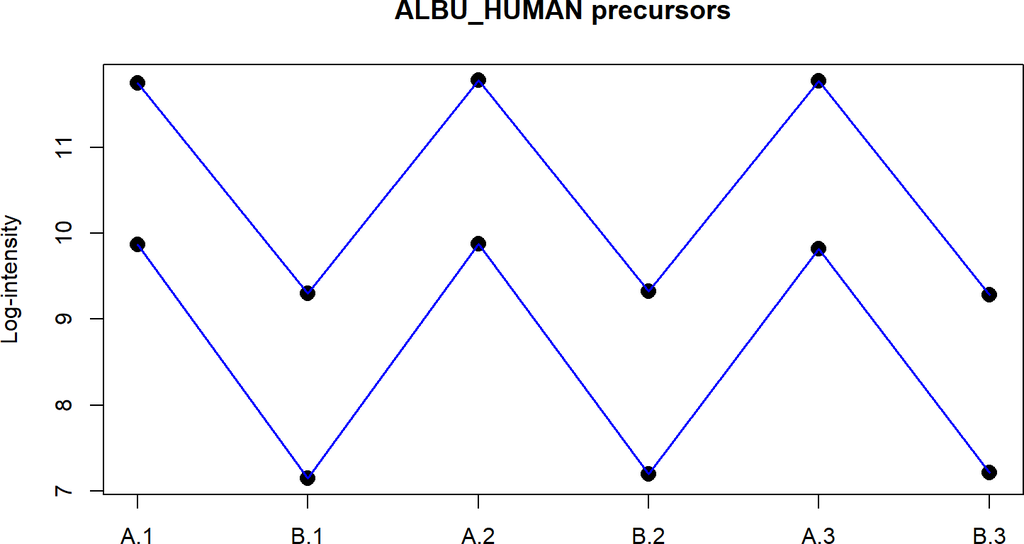

```r
> i <- grep("ALBU_HUMAN",y.prec$genes$Protein.Group)
> plotPeptides(y.prec[i,], main="ALBU_HUMAN precursors")
```

The fact that human albumin appears DE is an artefact of the dataset rather than an error of the statistical testing method.

# Further reading

More documentation and example analyses are available from https://github.com/SmythLab/limpa/.

# Cited references

Demichev V, Messner CB, Vernardis SI, Lilley KS, Ralser M (2020). DIA-NN: neural networks and interference correction enable deep proteome coverage in high throughput. *Nature Methods* 17(1), 41-44.

Li M, Cobbold SA, Smyth GK (2025). Quantification and differential analysis of mass spectrometry proteomics data with probabilistic recovery of information from missing values. *bioRxiv* 2025/651125. [doi:10.1101/2025.04.28.651125](https://doi.org/10.1101/2025.04.28.651125)

Navarro P, Kuharev J, Gillet LC, Bernhardt OM, MacLean B, Rost HL, Tate SA, Tsou CC, Reiter L, Distler U, Rosenberger G, Perez-Riverol Y, Nesvizhskii AI, Aebersold R, Tenzer S (2016). A multicenter study benchmarks software tools for label-free proteome quantification. *Nature Biotechnology*, 34(11), 1130-1136.